# Najlepiej oceniane gry na Metacritic - analiza

Autor

Patryk Tokarski

# Wprowadzenie

Zbióry danych, które posłużą nam dzisiaj do analizy pobrałem za pomocą narzędzi webscrapingu ze strony [Metacritic](https://www.metacritic.com/browse/games/score/metascore/all/all/filtered?sort=desc&view=detailed). Jeden z nich zawiera 100 najlepiej ocenianych gier przez krytyków w historii. Drugi zawiera 1000 obserwacji, które są połączeniem najlepszych gier z lat 2013-2022 (po sto na każdy rok). Do pierwszego będę się odwoływał jako “zbiór 100 najlepszych”, a do drugiego “zbiorem 1000 najlepszych” gier.

Każda z gier w serwisie Metacritic ma osobną ocenę dla każdej z platform, na której miała premierę. Aby gra znalazła się w tym zestawieniu, musiała posiadać przynajmniej 7 ocen krytyków, którymi są najważniejsze serwisy lub magazyny zajmujące się grami.

Każda z obserwacji zawiera pięć parametrów:

- tytuł,
- platformę, na której została wydana gra,
- datę wydania gry,
- ocenę krytyków (0-100),
- ocenę użytkowników (0-100)

Tabela 1: Dziewięć pierwszych (najlepszych) gier ze zbioru danych

| **Tytuł** | **Platforma** | **Data wydania** | **Ocena krytyków** | **Ocena użytkowników** |
| --- | --- | --- | --- | --- |
| The Legend of Zelda: Ocarina of Time | Nintendo64 | 1998-11-23 | 99 | 91 |
| Tony Hawk's Pro Skater 2 | PlayStation | 2000-09-20 | 98 | 74 |
| Grand Theft Auto IV | PlayStation3 | 2008-04-29 | 98 | 78 |
| SoulCalibur | Dreamcast | 1999-09-08 | 98 | 84 |
| Grand Theft Auto IV | Xbox360 | 2008-04-29 | 98 | 80 |
| Super Mario Galaxy | Wii | 2007-11-12 | 97 | 91 |
| Super Mario Galaxy 2 | Wii | 2010-05-23 | 97 | 91 |
| Red Dead Redemption 2 | XboxOne | 2018-10-26 | 97 | 82 |
| Grand Theft Auto V | XboxOne | 2014-11-18 | 97 | 79 |

# Analiza

### Podsumowanie parametrów ilościowych

Tabela 2: Zbiór 100 najlepszych

| **Parametr** | **n** | **min** | **max** | **q1** | **Mediana** | **q1** |
| --- | --- | --- | --- | --- | --- | --- |
| Ocena krytyków | 100 | 94 | 99 | 94 | 95 | 96.00 |
| Ocena użytkowników | 100 | 62 | 93 | 83 | 87 | 89.25 |

Tabela 3: Zbiór 1000 najlepszych

| **Parametr** | **n** | **min** | **max** | **q1** | **Mediana** | **q1** |
| --- | --- | --- | --- | --- | --- | --- |
| Ocena krytyków | 1000 | 83 | 97 | 85 | 86 | 88 |
| Ocena użytkowników | 996 | 18 | 92 | 73 | 79 | 83 |

Jak możemy zauważyć, w obu przypadkach wysokie oceny krytyków niekoniecznie oznaczą także wysokie oceny użytkowników.

Tabela 4: Średnie oceny użytkowników i krytyków w poszczególnych latach

| Rok wydania | Średnia ocena krytyków | Średnia ocena użytkowników |
| --- | --- | --- |
| 2013 | 86 | 79.5 |
| 2014 | 85 | 78.0 |
| 2015 | 86 | 80.0 |
| 2016 | 87 | 78.0 |
| 2017 | 86 | 80.0 |
| 2018 | 87 | 80.0 |
| 2019 | 86 | 79.0 |
| 2020 | 86 | 78.5 |
| 2021 | 87 | 79.0 |
| 2022 | 87 | 78.0 |

Średnia ocena najlepszych gier według krytyków oraz użytkowników na przestrzeni lat jest stabilna oraz wynosi odpowiednio 86 i 79.

### W którym roku zostały wydane gry oceniane przez krytyków jako najlepsze?

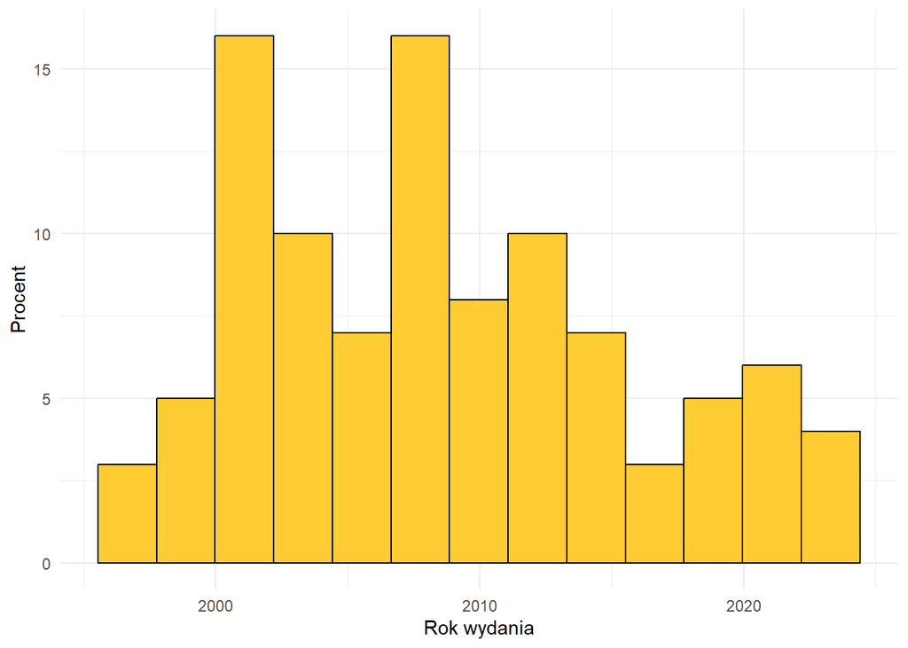

Rysunek 1: Wykres pokazujący w którym roku wydane zostały gry znajdujące się w top 100 najlepszych gier

### Zmiana platform w czasie

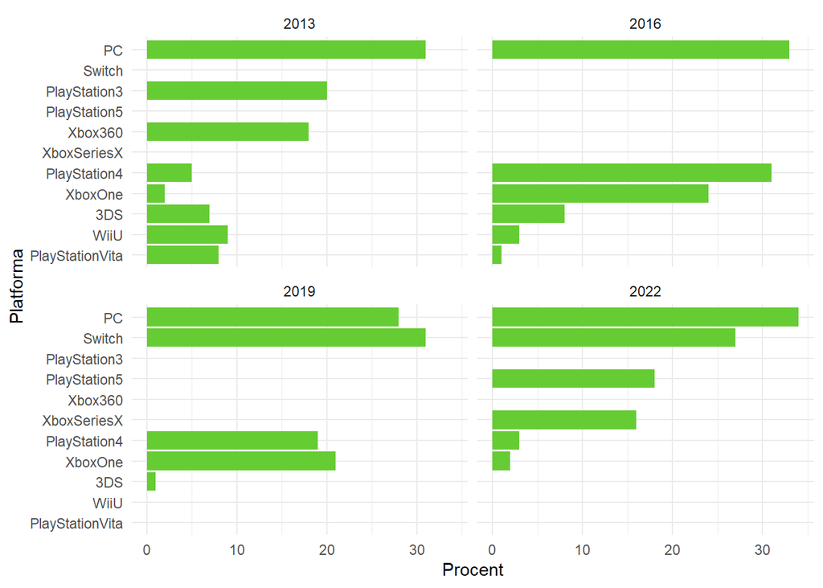

Rysunek 2: Na których platformach wychodziły najlepsze gry w wybranych latach z przedziału 2013-2022? (wybrałem cztery lata, ponieważ przy większej ilości wykresów ciężej byłoby dostrzec różnice pomiędzy nimi)

Na Rysunku 2 możemy zaobserwować zmiany platform, na których wychodziły najlepsze gry. Wszystkie łączy to, że nieprzerwanie w gronie najpopularniejszych platform może cieszyć się PC. Poza tym w 2013 roku widzimy dominację konsol PlayStation3 oraz Xbox360. W tym także roku popularne były platformy takie jak 3DS, WiiU i PSVita, które jednak swoją młodość miały już za sobą i musiały w przyszłych latach ustąpić miejsca nowszym konsolom. W 2016 roku najpopularniejsze były Playstation4 oraz XboxOne, czyli kolejna generacja konsol. W 2019 roku dołączyła do nich przenośna konsola Switch, która przebiła w ilości najlepszych gier komputery PC! Na ostatnim wykresie, czyli roku 2022 przyszła kolejna generacja czołowych konsol (Playstation5, XboxSeries) i to ona, wraz ze Switchem i komputerami PC aktualnie dominuje na rynku.

### Platforma z największą ilością topowych gier w danym roku

Tabela 5: Najpopularniejsza platforma z top 10 najlepszych gier w latach 2013-2022

| Rok | Platforma | Ilość gier z 10 najlepszych |
| --- | --- | --- |
| 2013 | PlayStation3 | 4 |
| 2014 | PlayStation4 | 5 |
| 2015 | PC | 4 |
| 2015 | PlayStation4 | 4 |
| 2016 | PC | 5 |
| 2017 | Switch | 5 |
| 2018 | XboxOne | 4 |
| 2018 | Switch | 4 |
| 2019 | PC | 3 |
| 2019 | PlayStation4 | 3 |
| 2020 | PC | 5 |
| 2021 | PC | 3 |
| 2021 | Switch | 3 |
| 2022 | PC | 4 |

### W których miesiącach są wydawane najlepsze gry?

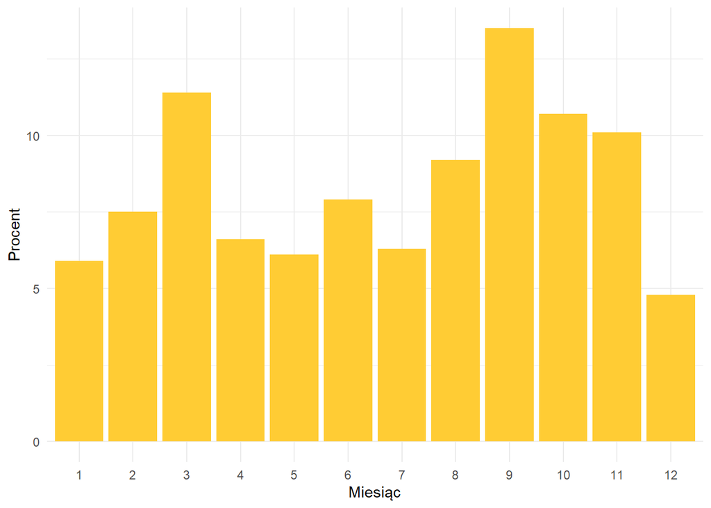

Rysunek 3: Ilość gier, które zostały wydane w danym miesiącu

Najwięcej premier topowych tytułów ma miejsce w marcu, wrześniu, październiku i listopadzie. Dużo premier w ostatnich miesiącach roku może być to spowodowane tym, że nagrody za gry roku wydawane są w grudniu, a tytuły gier niedawno ogrywanych łatwiej jest nam sobie przypomnieć niż tych ogrywanych wcześniej.

### W którym dniu tygodnia wydawane są najlepsze gry?

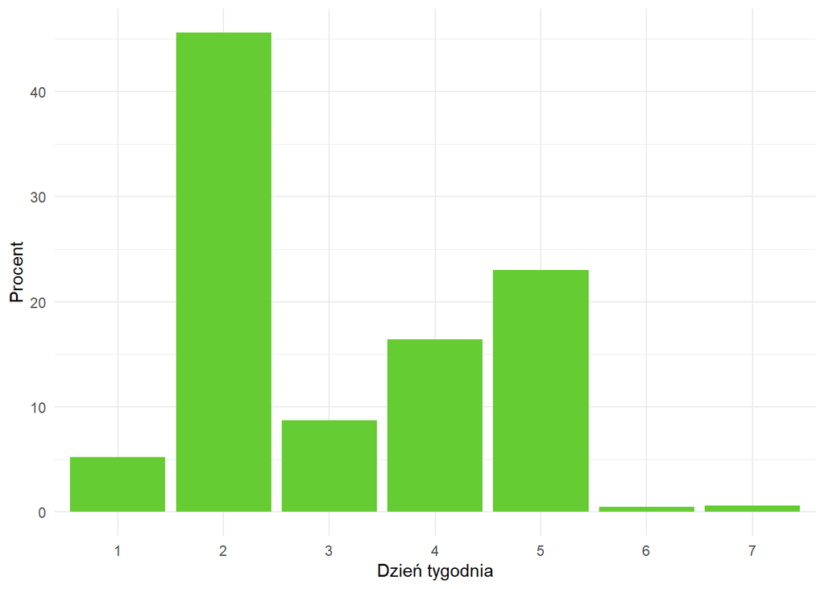

Rysunek 4: Ilość gier, które zostały wydane w danym dniu tygodnia

Możemy zauważyć, że bardzo dużo tytułów (>40%) ma swoją premierę we wtorki. W internecie nie byłem w stanie znaleść zweryfikowanej odpowiedzi na pytanie, dlaczego akurat to w ten dzień jest najwięcej wydawanych gier. Tworzonych jest jednak wiele teorii. Jedna z nich twierdzi, że jest to spowodowane kwestiami logistycznymi. Inna natomiast twierdzi, że pochodzi to od zabiegu marketingowego zastosowanego przy premierze Sonica[^1]. Ciekawym jest też to, że znikoma ilość tytułów ma premierę w sobotę i niedzielę.

### Na której platformie było najwięcej z top 100 najlepiej ocenianych gier?

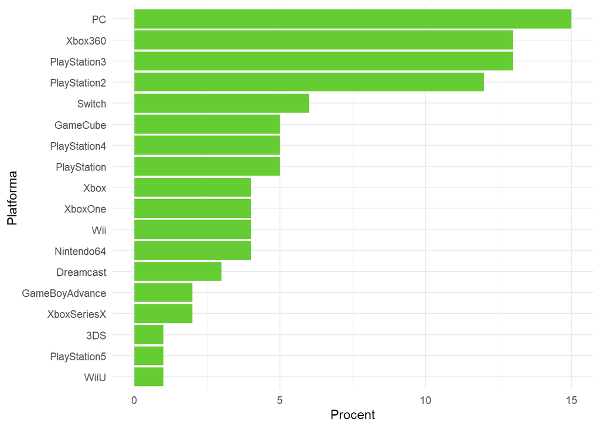

Rysunek 5: Jaki procent tytułów w zbiorze 100 najlepszych gier wyszedł na danej platformie?

Na Rysunku 5 możemy dostrzec cztery platformy, które są w czołówce. Są to PC, Xbox360, PlayStation3 i PlayStation2, na których wyszła ponad połowa najlepszych gier.

### Najlepszy tytuł na daną platformę

Tabela 6: Najlepiej oceniana gra na poszczególnych platformach

| **Platforma** | **Tytuł** | **Rok wydania** | **Ocena krytyków** |
| --- | --- | --- | --- |
| Nintendo64 | The Legend of Zelda: Ocarina of Time | 1998 | 99 |
| PlayStation | Tony Hawk's Pro Skater 2 | 2000 | 98 |
| PlayStation3 | Grand Theft Auto IV | 2008 | 98 |
| Dreamcast | SoulCalibur | 1999 | 98 |
| Xbox360 | Grand Theft Auto IV | 2008 | 98 |
| Wii | Super Mario Galaxy | 2007 | 97 |
| XboxOne | Red Dead Redemption 2 | 2018 | 97 |
| PC | Disco Elysium: The Final Cut | 2021 | 97 |
| Switch | The Legend of Zelda: Breath of the Wild | 2017 | 97 |
| PlayStation2 | Tony Hawk's Pro Skater 3 | 2001 | 97 |
| PlayStation4 | Red Dead Redemption 2 | 2018 | 97 |
| GameCube | Metroid Prime | 2002 | 97 |
| Xbox | Halo: Combat Evolved | 2001 | 97 |
| WiiU | The Legend of Zelda: Breath of the Wild | 2017 | 96 |
| XboxSeriesX | Elden Ring | 2022 | 96 |
| PlayStation5 | Elden Ring | 2022 | 96 |
| GameBoyAdvance | The Legend of Zelda: A Link to the Past | 2002 | 95 |
| 3DS | The Legend of Zelda: Ocarina of Time 3D | 2011 | 94 |

# Podsumowanie i wnioski

Dane o najlepszych grach z serwisu Metacritic dają wiele ciekawych spostrzeżeń:

Jednak najciekawszą i najbardziej tajemniczą ciekawostką dla mnie było to, że we wtorki premierę ma najwięcej gier (Patrz Rysunek 4). Zakładałem, że najpopularniejszym dniem będzie piątek, ponieważ to zazwyczaj wtedy premierę mają albumy muzyczne i filmy. A jednak medium jakim są gry komputerowe pod tym względem odstają od reszty dzieł kultury.

## Przypisy

[^1]: https://www.businessinsider.in/The-Weird-Reason-Why-Video-Games-Are-Released-On-Tuesdays/articleshow/45117573.cms